# test_perceptual_phenomenon

```python
cd C:\\Users\\Abhishek\\Downloads
```

```
C:\Users\Abhishek\Downloads
```

```python
# ------------------------------Test a Perceptual Phenomenon-----------------------
```

## Q.1 What our independent variable ?What is our dependent variable?

The two main variables in an experiment are the independent and dependent variable. An independent variable is the variable that is changed or controlled in a scientific experiment to test the effects on the dependent variable.If the independent variable is changed, then an effect is seen in the dependent variable. The given data set stroopdata.csv contains both an independent and dependent variable. In this experiment, the dependent variable is the response time for each participant to name the ink color and the independent variable is the congruency condition including congruent words condition and incongruent words condition.

## Q.2 What is an appropriate set of hypothesis for this task ?What kind of statistical test do you expect to perform ?justify your choices

ANSWER: -I choose the two tailed t-test for my given data set. The dependent t-test compares the mean of two paired groups to see if there are statistically significant differences between these means. The same subjects were tested for congruent and incongruent words. By using the same subject to test two different condition, we eliminate the individual differences that occur between subjects.

Reason of Selecting two tailed test

- We don't have direction of the test so we choose two tailed test.
- We don't have any imformation about the population, we have just 24 sample datasets.
- The ability to compare the means of the dataset for the pre and post test validates the benefit of this test selection

Assumptions:

```
- Normality: The distribution of the differences in the dependent variable between the two related groups should be approximately normally distributed. Normal distributions are symmetric around the center(mean) and follow a ‘bell- shaped’ distribution.
- The observations are independent of one another.
- Dependent variable should be measured on a continuous scale. The dependent t-test requires the sample data to be numeric and continuous, as it is based on the normal distribution.


Hypothesis:

1.NULL hypothesis:-A null hypothesis is a statistical hypothesis in which there is no significant difference exist between the set of variables. It is the original or default statement, with no effect, often represented by H0 (H-zero). In this experiment the null hypothesis is that there is no significant difference exist between the time taken to say the congruent words and incongruent words, means the Mean (xbar) of the Reaction time for the congruent sample will be equal to the mean(xbar) of the reaction time for the incongruent sample.

2.Alternate hypothesis:- A alternative hypothesis is a statistical hypothesis in which there is no significant difference exist between the set of variables. Often denoted by H1 (H-one).In this experiment the alternative hypothesis is that there is significant difference exist between the time taken to say the congruent words and incongruent words, means the Mean (xbar) of the Reaction time for the congruent sample will not be equal to the mean(xbar) of the reaction time for the incongruent sample.

H0(Null hypothesis):              (Population Mean)incongurent =(Population Mean)incongurent
H1(Alternate hypothesis):         (Population Mean)incongurent !=(Population Mean)incongurent
```

- Where Ui = Mean time taken to name the ink color for incongruent words.
- uc = Mean time taken to name the ink color for congruent words.
- if we get a significant result, we can reject the null hypothesis and accept the alternative hypothesis that there are statistically significant differences between the mean time taken to name ink color between two test conditions.

## Q.3 Report some descriptive statistics regarding this data include atleast one measure of central tendancy and atleast one measure of variablity?

```python
#Q.3 solution
import pandas as pd
import numpy as np
import math
import seaborn as sns
import matplotlib.pyplot as plt
from scipy.stats import t as pt
%matplotlib inline
#Read the data and print it
d=pd.read_csv('stroopdata.csv')
print(d)
#Detail about the data set
print(d.describe())
#Find the mean median and standard deviation of both column of dataFrame
cong_mean=d['Congruent'].mean()
incong_mean=d['Incongruent'].mean()
cong_median=d['Congruent'].median()
incong_median=d['Incongruent'].median()
cong_std=d['Congruent'].std()
incong_std=d['Incongruent'].std()
a=[[int(24),int(24)],[cong_mean,incong_mean],[cong_median,incong_median],[cong_std,incong_std]]
data=pd.DataFrame(a,index=['Sample Size','Mean','Median','Standard Deviation'],columns=['Congruent','Incongruent'])
#printing the mean meadian and standard deviation of both column Congruent and Incongruent
print(data)
```

```
    Congruent  Incongruent
0      12.079       19.278
1      16.791       18.741
2       9.564       21.214
3       8.630       15.687
4      14.669       22.803
5      12.238       20.878
6      14.692       24.572
7       8.987       17.394
8       9.401       20.762
9      14.480       26.282
10     22.328       24.524
11     15.298       18.644
12     15.073       17.510
13     16.929       20.330
14     18.200       35.255
15     12.130       22.158
16     18.495       25.139
17     10.639       20.429
18     11.344       17.425
19     12.369       34.288
20     12.944       23.894
21     14.233       17.960
22     19.710       22.058
23     16.004       21.157
       Congruent  Incongruent
count  24.000000    24.000000
mean   14.051125    22.015917
std     3.559358     4.797057
min     8.630000    15.687000
25%    11.895250    18.716750
50%    14.356500    21.017500
75%    16.200750    24.051500
max    22.328000    35.255000
                    Congruent  Incongruent
Sample Size         24.000000    24.000000
Mean                14.051125    22.015917
Median              14.356500    21.017500
Standard Deviation   3.559358     4.797057
```

## Q.4 Provide one or two visualization that show the distribution of the sample data .Write one or two sentences noting what you observe about plot or plots?

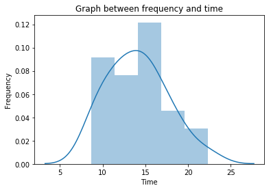

```python
#Q.4 solution
#Histogram for congruent column
sns.distplot(d['Congruent'])
plt.xlabel('Time');plt.ylabel('Frequency');plt.title('Graph between frequency and time');
```

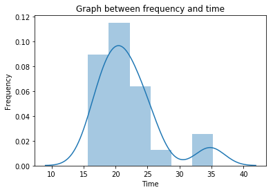

```python
#Q.4 solution
#Histogram for incongruent column
sns.distplot(d['Incongruent'])
plt.xlabel('Time');plt.ylabel('Frequency');plt.title('Graph between frequency and time');
```

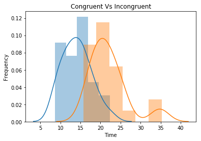

```python
#Q.4 solution
#comparing graph for both the congruent and incongruent column
sns.distplot(d['Congruent'],label='Congruent')
sns.distplot(d['Incongruent'],label='Incongruent')
plt.xlabel('Time');plt.ylabel('Frequency');plt.title('Congruent Vs Incongruent');
```

Both of these two distribution looks like Normal distribution but their mean is different .

## Q.5 Now,perform the statistical test and report your result .What is your confidence level and your crictical statistic value ? Do you reject the null hypothesis or fail to reject it ? Come to a conclusion in terms of experiment task .Did the results match up with your expectation ?

Ans

- Sample Size(n)=24
- Degree of freedom (df)=n-1=24-1=23
- Test is two tailed t-test.Here we find crictical value of t at 95% confidence level

```python
#Q.5
#Finding the t-critical value for 95% confidence interval for two tailed test and here degree of
#freedom is 23
print(pt.ppf(0.975,23),5)
#making an new column which contain the difference of this two column
d['difference']=d['Congruent']-d['Incongruent']
#finding the mean and standard deviation of difference dataset
diff_mean=d['difference'].mean()
diff_std=d['difference'].std()
print(round(diff_mean,5))
print(round(diff_std,5))
#finding the t-value
t_value=diff_mean/(diff_std/math.sqrt(24))
print(t_value)
print(d)
```

```
2.0686576104190406 5
-7.96479
4.86483
-8.020706944109957
    Congruent  Incongruent  difference
0      12.079       19.278      -7.199
1      16.791       18.741      -1.950
2       9.564       21.214     -11.650
3       8.630       15.687      -7.057
4      14.669       22.803      -8.134
5      12.238       20.878      -8.640
6      14.692       24.572      -9.880
7       8.987       17.394      -8.407
8       9.401       20.762     -11.361
9      14.480       26.282     -11.802
10     22.328       24.524      -2.196
11     15.298       18.644      -3.346
12     15.073       17.510      -2.437
13     16.929       20.330      -3.401
14     18.200       35.255     -17.055
15     12.130       22.158     -10.028
16     18.495       25.139      -6.644
17     10.639       20.429      -9.790
18     11.344       17.425      -6.081
19     12.369       34.288     -21.919
20     12.944       23.894     -10.950
21     14.233       17.960      -3.727
22     19.710       22.058      -2.348
23     16.004       21.157      -5.153
```

t-critical value is:2.0686576104190406 standard_deviation of differenced column:4.86483 Mean of the differenced column:-7.96479

```python
t_value=diff_mean/(diff_std/math.sqrt(24))
print("The t-value is: ",t_value)
```

```
The t-value is:  -8.020706944109957
```

- The calculated t-statistic is -8.0207 for the difference in colour recognition time means of the congruent and incongruent words data. And -8.0207 is much lower than the t-critical value. Since the t-statistic is in the critical region, so the null hypothesis is rejected.
- Null hypothesis rejected At α = 0.05, the time to name colours is significantly different between congruent and incongruent tasks. People do not name colours at the same speed when the word’s meaning and its colour match, as when they do not match. The result confirms my expectations.

## Q.6 What do you think is responsible for the effect observed?can you think of an alternative or similar task that would result in a similar effect? Some research about the problem will be helpful for thinking these two questions?

ANSWER:

The brain has an image association between the shape of the word and the colour. When there is a mismatch, additional time is necessary for the prefrontal cortex to process the information and decide on its meaning.The words themselves have a strong influence over your ability to say the color. The interference between the different information (what the words say and the color of the words) your brain receives causes a problem. There are two theories that may explain the Stroop effect:

Speed of Processing Theory: the interference occurs because words are read faster than colors are named. Selective Attention Theory: the interference occurs because naming colors requires more attention than reading words Similar effect to the this effect can be reserve stroop effect.In this test the participant’s task is to say out loud the word that is printed not its color.